# Exploring scraped immowelt.de Apartment data for North Rhine-Westphalia (May 2022)

Author: [Michael Volk](https://github.com/micvolk)

## Introduction

In this Jupyter-Notebook scraped and prepared apartment-exposes-data for buy & rent from immowelt.de for the german federal state North Rhine-Westphalia as of May 2022 is explored. For the exploration descriptive statistics techniques like univariate and multivariate analysis are used. Also geographic analysis regarding prices per area in North Rhine Westphalia and regarding rent-to-buy-price-ratio is performed.

This Jupyter-Notebook is part of my project: micvolk.github.io/Buy-and-Rent-Price-Estimator-for-Apartments  
Visit the website and get a detailed description of the project steps - starting from scraping, preparing and exploring the data from immowelt.de, evaluating different machine learning models and ending with transferring the best model into production by building a Web-App.  
To use the Web-App please follow this link: price-estimator-apartment-nrw.herokuapp.com

### Previous steps with own developed Python-modules

- *scraping.py*: apartment-expose-data has been scraped from immowelt.de in May 2022 with an own built web-scraper. The scraped data includes apartment-exposes in german state North Rhine-Westphalia for buy and for rent - the exposes-data has been saved as pandas-dataframes (pickled in csv-files) - one for buy and one for rent.
- *cleaning.py*: Scraped data has been cleaned (dropping apartments which did not match certain conditions and dropping useless features)
- *featureEngineering.py*: Cleaned data has been feature-engineered (mapping of values, extracting information from apartment-description text, ...) and saved as pandas-dataframes (pickled in csv-files) - one for buy and one for rent.

### Sources

The 2 generated csv-files of *featureEngineering.py* and a shapefile-map of North rhine-westphalia are the sources for this Jupyter-Notebook:

- *featureEngineered_buy.csv*
- *featureEngineered_rent.csv*
- *shapefiles\dvg2gem_nw.shp* (Source: https://www.opengeodata.nrw.de/produkte/geobasis/vkg/dvg/dvg2/)

### Sections

- First look on buy- & rent-dataframe
- Univariate Analysis
  - Descriptive statistics for each variable
  - Histograms
- Multivariate Analysis
  - Correlation-heatmap
  - Scatterplots & barplots regarding the price-variables
- Geographic Analysis
  - Apartment locations and their prices per area visualised in map of North Rhine-Westphalia
  - Comparing price-per-area and rent-to-buy-price-ratio between cities

## First look on buy- & rent-dataframe

### Number of rows and columns

**Buy:** (number of rows, number of columns)

```
(2499, 31)
```

**Rent:** (number of rows, number of columns)

```
(3200, 33)
```

### First rows

**Buy:**

|  | Price_buy | Price_buy_perArea | Area | Rooms | ConstructionYear | City | City_district | Latitude | Longitude | EQ_CAT_unknown | EQ_CAT_floorApartment | EQ_CAT_apartment | EQ_CAT_maisonette | EQ_CAT_penthouse | EQ_CAT_terraceApartment | EQ_CAT_loft | EQ_CON_unknown | EQ_CON_firstOccupancy | EQ_CON_upscale | EQ_CON_maintained | EQ_CON_renovated | EQ_CON_needsRenovation | EQ_CON_refurbished | EQ_CON_needsRefurbishment | EQ_CON_partlyRenovated | EQ_OUT_balcony | EQ_OUT_garden | EQ_OUT_loggia | EQ_OUT_terrace | … |
| --- | --- | --- | --- | --- | --- | --- | --- | --- | --- | --- | --- | --- | --- | --- | --- | --- | --- | --- | --- | --- | --- | --- | --- | --- | --- | --- | --- | --- | --- | --- |
| 0 | 590000.00 | 3687.50 | 160.00 | 5.50 | 2010.00 | Lippstadt | Kernstadt | 51.67 | 8.35 | 0 | 1 | 0 | 0 | 0 | 0 | 0 | 0 | 0 | 1 | 0 | 0 | 0 | 0 | 0 | 0 | 1 | 0 | 0 | 0 | … |
| 1 | 476000.00 | 4666.67 | 102.00 | 4.00 | 1955.00 | Düsseldorf | Mörsenbroich | 51.25 | 6.81 | 1 | 0 | 0 | 0 | 0 | 0 | 0 | 0 | 0 | 0 | 1 | 0 | 0 | 0 | 0 | 0 | 1 | 0 | 0 | 0 | … |
| 2 | 165000.00 | 2462.69 | 67.00 | 2.00 | 1986.00 | Bad Salzuflen | Innenstadt | 52.10 | 8.75 | 0 | 1 | 0 | 0 | 0 | 0 | 0 | 0 | 0 | 1 | 0 | 0 | 0 | 0 | 0 | 0 | 1 | 0 | 0 | 0 | … |
| 3 | 519400.00 | 4900.00 | 106.00 | 3.00 | 1984.00 | Köln | Niehl | 50.98 | 6.96 | 1 | 0 | 0 | 0 | 0 | 0 | 0 | 0 | 0 | 1 | 1 | 1 | 0 | 0 | 0 | 1 | 0 | 1 | 1 | 1 | … |
| 4 | 359800.00 | 4283.33 | 84.00 | 3.00 | 2021.00 | Leopoldshöhe | Bechterdissen | 52.00 | 8.67 | 1 | 0 | 0 | 0 | 0 | 0 | 0 | 0 | 1 | 0 | 0 | 0 | 0 | 0 | 0 | 0 | 0 | 1 | 0 | 0 | … |

**Rent:**

|  | Price_rent_cold | Price_rent_cold_perArea | Price_rent_warm | Price_rent_warm_perArea | Area | Rooms | ConstructionYear | City | City_district | Latitude | Longitude | EQ_CAT_unknown | EQ_CAT_floorApartment | EQ_CAT_apartment | EQ_CAT_maisonette | EQ_CAT_penthouse | EQ_CAT_terraceApartment | EQ_CAT_loft | EQ_CON_unknown | EQ_CON_firstOccupancy | EQ_CON_upscale | EQ_CON_maintained | EQ_CON_renovated | EQ_CON_needsRenovation | EQ_CON_refurbished | EQ_CON_needsRefurbishment | EQ_CON_partlyRenovated | EQ_OUT_balcony | EQ_OUT_garden | … |
| --- | --- | --- | --- | --- | --- | --- | --- | --- | --- | --- | --- | --- | --- | --- | --- | --- | --- | --- | --- | --- | --- | --- | --- | --- | --- | --- | --- | --- | --- | --- |
| 0 | 563.50 | 7.00 | 855.00 | 10.62 | 80.50 | 2.50 | 1901.00 | Herne | Eickel | 51.51 | 7.18 | 1 | 0 | 0 | 0 | 0 | 0 | 0 | 0 | 0 | 0 | 0 | 1 | 0 | 1 | 0 | 0 | 1 | 0 | … |
| 1 | 301.72 | 5.11 | nan | nan | 59.00 | 2.00 | 2015.00 | Geseke | Geseke | 51.63 | 8.52 | 1 | 0 | 0 | 0 | 0 | 0 | 0 | 1 | 0 | 0 | 0 | 0 | 0 | 0 | 0 | 0 | 0 | 0 | … |
| 2 | 305.00 | 6.00 | 401.00 | 7.88 | 50.86 | 2.00 | 1951.00 | Herne | Herne-Süd | 51.53 | 7.23 | 0 | 1 | 0 | 0 | 0 | 0 | 0 | 1 | 0 | 0 | 0 | 0 | 0 | 0 | 0 | 0 | 0 | 0 | … |
| 3 | 640.00 | 8.00 | 880.00 | 11.00 | 80.00 | 3.00 | 1997.00 | Mönchengladbach | Eicken | 51.21 | 6.45 | 0 | 1 | 0 | 0 | 0 | 0 | 0 | 0 | 0 | 0 | 1 | 0 | 0 | 0 | 0 | 0 | 1 | 0 | … |
| 4 | 560.00 | 6.59 | 740.00 | 8.71 | 85.00 | 3.00 | 1993.00 | Lindlar | Lindlar | 51.02 | 7.37 | 0 | 1 | 0 | 0 | 0 | 0 | 0 | 0 | 0 | 0 | 1 | 0 | 0 | 0 | 0 | 0 | 1 | 0 | … |

**Explanations:**

- Price variables are denominated in €
- 'Area' is measured in square-metres
- Variables with prefix 'EQ_' (stands for apartment-equipment) can only take the values:
  - 1: 'Yes'
  - 0: 'No'
- Subsequent prefixes of variables with prefix 'EQ_' can be:
  - 'CAT_': stands for apartment-category
  - 'CON_': stands for apartment-condition
  - 'OUT_': stands for apartment-outdoor-equipment
- 'Url' links to the original apartment-expose of immowelt.de
- 'geometry' contains the information of the variables 'Latitude' & 'Longitude' converted to the coordinate-reference-system epsg:25832

### Share of missing values

Buy: Share of missing values per column

|  | Buy |
| --- | --- |
| Price_buy | 0.0% |
| Price_buy_perArea | 0.0% |
| Area | 0.0% |
| Rooms | 0.0% |
| ConstructionYear | 0.0% |
| City | 0.0% |
| City_district | 1.1% |
| Latitude | 0.0% |
| Longitude | 0.0% |
| EQ_CAT_unknown | 0.0% |
| EQ_CAT_floorApartment | 0.0% |
| EQ_CAT_apartment | 0.0% |
| EQ_CAT_maisonette | 0.0% |
| EQ_CAT_penthouse | 0.0% |
| EQ_CAT_terraceApartment | 0.0% |
| EQ_CAT_loft | 0.0% |
| EQ_CON_unknown | 0.0% |
| EQ_CON_firstOccupancy | 0.0% |
| EQ_CON_upscale | 0.0% |
| EQ_CON_maintained | 0.0% |
| EQ_CON_renovated | 0.0% |
| EQ_CON_needsRenovation | 0.0% |
| EQ_CON_refurbished | 0.0% |
| EQ_CON_needsRefurbishment | 0.0% |
| EQ_CON_partlyRenovated | 0.0% |
| EQ_OUT_balcony | 0.0% |
| EQ_OUT_garden | 0.0% |
| EQ_OUT_loggia | 0.0% |
| EQ_OUT_terrace | 0.0% |
| Url | 0.0% |
| geometry | 0.0% |

Rent: Share of missing values per column

|  | Rent |
| --- | --- |
| Price_rent_cold | 0.0% |
| Price_rent_cold_perArea | 0.0% |
| Price_rent_warm | 33.3% |
| Price_rent_warm_perArea | 33.3% |
| Area | 0.0% |
| Rooms | 0.0% |
| ConstructionYear | 0.0% |
| City | 0.0% |
| City_district | 0.9% |
| Latitude | 0.0% |
| Longitude | 0.0% |
| EQ_CAT_unknown | 0.0% |
| EQ_CAT_floorApartment | 0.0% |
| EQ_CAT_apartment | 0.0% |
| EQ_CAT_maisonette | 0.0% |
| EQ_CAT_penthouse | 0.0% |
| EQ_CAT_terraceApartment | 0.0% |
| EQ_CAT_loft | 0.0% |
| EQ_CON_unknown | 0.0% |
| EQ_CON_firstOccupancy | 0.0% |
| EQ_CON_upscale | 0.0% |
| EQ_CON_maintained | 0.0% |
| EQ_CON_renovated | 0.0% |
| EQ_CON_needsRenovation | 0.0% |
| EQ_CON_refurbished | 0.0% |
| EQ_CON_needsRefurbishment | 0.0% |
| EQ_CON_partlyRenovated | 0.0% |
| EQ_OUT_balcony | 0.0% |
| EQ_OUT_garden | 0.0% |
| EQ_OUT_loggia | 0.0% |
| EQ_OUT_terrace | 0.0% |
| Url | 0.0% |
| geometry | 0.0% |

**Results:**

- Thanks to preprocessing with *cleaning.py* and *featureEngineering.py* all relevant columns have no missing values

## Univariate Analysis

### Descriptive statistics for numeric columns

**Buy:**

|  | Price_buy | Price_buy_perArea | Area | Rooms | ConstructionYear | Latitude | Longitude | EQ_CAT_unknown | EQ_CAT_floorApartment | EQ_CAT_apartment | EQ_CAT_maisonette | EQ_CAT_penthouse | EQ_CAT_terraceApartment | EQ_CAT_loft | EQ_CON_unknown | EQ_CON_firstOccupancy | EQ_CON_upscale | EQ_CON_maintained | EQ_CON_renovated | EQ_CON_needsRenovation | EQ_CON_refurbished | EQ_CON_needsRefurbishment | EQ_CON_partlyRenovated | EQ_OUT_balcony | EQ_OUT_garden | EQ_OUT_loggia | EQ_OUT_terrace |
| --- | --- | --- | --- | --- | --- | --- | --- | --- | --- | --- | --- | --- | --- | --- | --- | --- | --- | --- | --- | --- | --- | --- | --- | --- | --- | --- | --- |
| count | 2499.00 | 2499.00 | 2499.00 | 2499.00 | 2499.00 | 2499.00 | 2499.00 | 2499.00 | 2499.00 | 2499.00 | 2499.00 | 2499.00 | 2499.00 | 2499.00 | 2499.00 | 2499.00 | 2499.00 | 2499.00 | 2499.00 | 2499.00 | 2499.00 | 2499.00 | 2499.00 | 2499.00 | 2499.00 | 2499.00 | 2499.00 |
| mean | 246214.53 | 3086.82 | 79.43 | 2.90 | 1972.07 | 51.34 | 7.19 | 0.33 | 0.55 | 0.03 | 0.06 | 0.02 | 0.01 | 0.00 | 0.36 | 0.02 | 0.09 | 0.46 | 0.05 | 0.05 | 0.05 | 0.01 | 0.00 | 0.50 | 0.18 | 0.06 | 0.12 |
| std | 164016.75 | 1492.84 | 27.97 | 1.01 | 25.08 | 0.37 | 0.62 | 0.47 | 0.50 | 0.17 | 0.24 | 0.13 | 0.11 | 0.05 | 0.48 | 0.14 | 0.29 | 0.50 | 0.23 | 0.21 | 0.21 | 0.09 | 0.07 | 0.50 | 0.38 | 0.23 | 0.32 |
| min | 44000.00 | 485.44 | 17.00 | 1.00 | 1870.00 | 50.43 | 6.00 | 0.00 | 0.00 | 0.00 | 0.00 | 0.00 | 0.00 | 0.00 | 0.00 | 0.00 | 0.00 | 0.00 | 0.00 | 0.00 | 0.00 | 0.00 | 0.00 | 0.00 | 0.00 | 0.00 | 0.00 |
| 25% | 139000.00 | 2021.13 | 61.00 | 2.00 | 1961.00 | 51.08 | 6.81 | 0.00 | 0.00 | 0.00 | 0.00 | 0.00 | 0.00 | 0.00 | 0.00 | 0.00 | 0.00 | 0.00 | 0.00 | 0.00 | 0.00 | 0.00 | 0.00 | 0.00 | 0.00 | 0.00 | 0.00 |
| 50% | 208900.00 | 2742.91 | 76.40 | 3.00 | 1973.00 | 51.33 | 7.04 | 0.00 | 1.00 | 0.00 | 0.00 | 0.00 | 0.00 | 0.00 | 0.00 | 0.00 | 0.00 | 0.00 | 0.00 | 0.00 | 0.00 | 0.00 | 0.00 | 1.00 | 0.00 | 0.00 | 0.00 |
| 75% | 299000.00 | 3774.31 | 93.47 | 3.50 | 1986.00 | 51.54 | 7.40 | 1.00 | 1.00 | 0.00 | 0.00 | 0.00 | 0.00 | 0.00 | 1.00 | 0.00 | 0.00 | 1.00 | 0.00 | 0.00 | 0.00 | 0.00 | 0.00 | 1.00 | 0.00 | 0.00 | 0.00 |
| max | 1800000.00 | 18376.07 | 180.00 | 7.00 | 2021.00 | 52.43 | 9.11 | 1.00 | 1.00 | 1.00 | 1.00 | 1.00 | 1.00 | 1.00 | 1.00 | 1.00 | 1.00 | 1.00 | 1.00 | 1.00 | 1.00 | 1.00 | 1.00 | 1.00 | 1.00 | 1.00 | 1.00 |

**Rent:**

|  | Price_rent_cold | Price_rent_cold_perArea | Price_rent_warm | Price_rent_warm_perArea | Area | Rooms | ConstructionYear | Latitude | Longitude | EQ_CAT_unknown | EQ_CAT_floorApartment | EQ_CAT_apartment | EQ_CAT_maisonette | EQ_CAT_penthouse | EQ_CAT_terraceApartment | EQ_CAT_loft | EQ_CON_unknown | EQ_CON_firstOccupancy | EQ_CON_upscale | EQ_CON_maintained | EQ_CON_renovated | EQ_CON_needsRenovation | EQ_CON_refurbished | EQ_CON_needsRefurbishment | EQ_CON_partlyRenovated | EQ_OUT_balcony | EQ_OUT_garden | EQ_OUT_loggia | EQ_OUT_terrace |
| --- | --- | --- | --- | --- | --- | --- | --- | --- | --- | --- | --- | --- | --- | --- | --- | --- | --- | --- | --- | --- | --- | --- | --- | --- | --- | --- | --- | --- | --- |
| count | 3200.00 | 3200.00 | 2135.00 | 2135.00 | 3200.00 | 3200.00 | 3200.00 | 3200.00 | 3200.00 | 3200.00 | 3200.00 | 3200.00 | 3200.00 | 3200.00 | 3200.00 | 3200.00 | 3200.00 | 3200.00 | 3200.00 | 3200.00 | 3200.00 | 3200.00 | 3200.00 | 3200.00 | 3200.00 | 3200.00 | 3200.00 | 3200.00 | 3200.00 |
| mean | 580.29 | 8.48 | 789.32 | 11.65 | 68.71 | 2.56 | 1966.11 | 51.40 | 7.22 | 0.42 | 0.49 | 0.05 | 0.02 | 0.01 | 0.01 | 0.00 | 0.44 | 0.03 | 0.07 | 0.30 | 0.17 | 0.01 | 0.11 | 0.00 | 0.01 | 0.48 | 0.12 | 0.02 | 0.08 |
| std | 321.50 | 3.07 | 371.16 | 3.68 | 24.12 | 0.84 | 28.62 | 0.32 | 0.59 | 0.49 | 0.50 | 0.21 | 0.15 | 0.09 | 0.08 | 0.04 | 0.50 | 0.17 | 0.25 | 0.46 | 0.38 | 0.10 | 0.32 | 0.03 | 0.08 | 0.50 | 0.33 | 0.13 | 0.27 |
| min | 169.00 | 3.25 | 225.94 | 2.32 | 12.83 | 1.00 | 1860.00 | 50.44 | 5.92 | 0.00 | 0.00 | 0.00 | 0.00 | 0.00 | 0.00 | 0.00 | 0.00 | 0.00 | 0.00 | 0.00 | 0.00 | 0.00 | 0.00 | 0.00 | 0.00 | 0.00 | 0.00 | 0.00 | 0.00 |
| 25% | 388.00 | 6.54 | 560.00 | 9.40 | 53.21 | 2.00 | 1954.00 | 51.22 | 6.86 | 0.00 | 0.00 | 0.00 | 0.00 | 0.00 | 0.00 | 0.00 | 0.00 | 0.00 | 0.00 | 0.00 | 0.00 | 0.00 | 0.00 | 0.00 | 0.00 | 0.00 | 0.00 | 0.00 | 0.00 |
| 50% | 490.00 | 7.73 | 689.74 | 10.88 | 65.00 | 2.50 | 1965.00 | 51.45 | 7.10 | 0.00 | 0.00 | 0.00 | 0.00 | 0.00 | 0.00 | 0.00 | 0.00 | 0.00 | 0.00 | 0.00 | 0.00 | 0.00 | 0.00 | 0.00 | 0.00 | 0.00 | 0.00 | 0.00 | 0.00 |
| 75% | 670.00 | 9.53 | 890.00 | 12.84 | 80.00 | 3.00 | 1983.00 | 51.54 | 7.46 | 1.00 | 1.00 | 0.00 | 0.00 | 0.00 | 0.00 | 0.00 | 1.00 | 0.00 | 0.00 | 1.00 | 0.00 | 0.00 | 0.00 | 0.00 | 0.00 | 1.00 | 0.00 | 0.00 | 0.00 |
| max | 3900.00 | 35.60 | 4400.00 | 43.60 | 179.76 | 6.00 | 2021.00 | 52.43 | 9.39 | 1.00 | 1.00 | 1.00 | 1.00 | 1.00 | 1.00 | 1.00 | 1.00 | 1.00 | 1.00 | 1.00 | 1.00 | 1.00 | 1.00 | 1.00 | 1.00 | 1.00 | 1.00 | 1.00 | 1.00 |

**Results:**

- Thanks to preprocessing with *cleaning.py* the target-variables Price_buy and Price_rent_cold don't seem to have extreme outliers

### Descriptive statistics for categorical columns

**Buy:**

|  | City | City_district | Url |
| --- | --- | --- | --- |
| count | 2499 | 2472 | 2499 |
| unique | 272 | 908 | 2499 |
| top | Köln | Innenstadt | https://www.immowelt.de/expose/248335y |
| freq | 234 | 73 | 1 |

**Rent:**

|  | City | City_district | Url |
| --- | --- | --- | --- |
| count | 3200 | 3171 | 3200 |
| unique | 272 | 916 | 3200 |
| top | Essen | Innenstadt | https://www.immowelt.de/expose/247kn5w |
| freq | 306 | 123 | 1 |

**Results:**

- Many cities with apartment offers for buy & rent in North Rhine-Westphalia

### Histograms regarding columns with numeric values

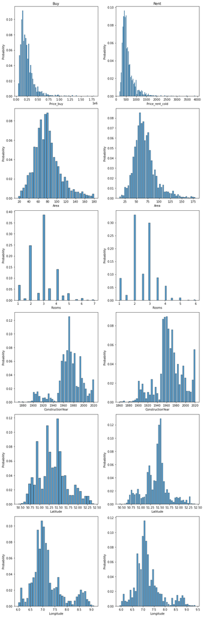

**Results:**

- Distributions of the price variables have a positive skew (=right-skewed) for buy & rent, so the mean-value is skewed to the right of the center of the data. That is not surprising as income and fortune distribution are typical examples for right-skewed distributions - and it seems to be obvious that apartment-prices are strongly positve correlated with income and fortune
- Also not surprisingly the 'Area' and 'Rooms' variables are right-skewed for buy & rent
- As a consequence of the right-skewness of the Price-, Area-, and Rooms-variables a normalization (via log-transform) will be performed for them in the next step to get a distribution which is more similiar to a normal-distribution - that helps for prediction with linear regression models in later steps
- Many relative old apartments are offered for buy and rent (big share of apartments with construction year between 1950 and 1970)
- Isolated distribution of Latitude or Longitude does not make much sense => combinated distribution can be seen on geographic map in section Geographic Analysis

### Histograms regarding log-transformed Price-, Area-, and Rooms-variables

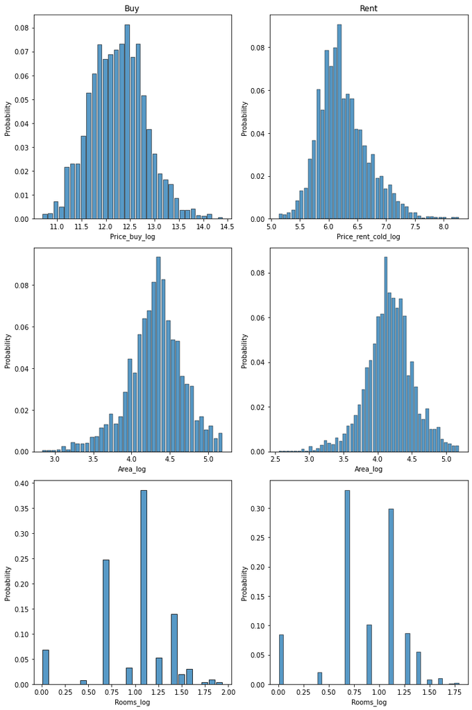

**Results:**

- Distributions of the log-transformed Price-, Area-, and Rooms-variables are much more similiar to a normal-distribution than without normalization - that helps for prediction with linear regression models in later steps.

### Top 10 cities with most apartments for buy & rent

Buy: Cities with most apartments

|  | Absolute | Relative |
| --- | --- | --- |
| Köln | 234 | 9.4% |
| Düsseldorf | 184 | 7.4% |
| Essen | 120 | 4.8% |
| Duisburg | 92 | 3.7% |
| Dortmund | 69 | 2.8% |
| Bonn | 57 | 2.3% |
| Bochum | 55 | 2.2% |
| Krefeld | 53 | 2.1% |
| Bielefeld | 53 | 2.1% |
| Wuppertal | 52 | 2.1% |

Rent: Cities with most apartments

|  | Absolute | Relative |
| --- | --- | --- |
| Essen | 306 | 9.6% |
| Gelsenkirchen | 208 | 6.5% |
| Dortmund | 192 | 6.0% |
| Duisburg | 168 | 5.2% |
| Düsseldorf | 161 | 5.0% |
| Bochum | 109 | 3.4% |
| Herne | 99 | 3.1% |
| Köln | 85 | 2.7% |
| Wuppertal | 72 | 2.2% |
| Hagen | 65 | 2.0% |

**Results:**

- Distributions regarding Top 10 cities with most apartments, measured in relative shares, differ clearly between buy- and rent-dataframe:
  - The 'Ruhrgebiet' region (Essen, Gelsenkirchen, Dortmund, ...) has much more offers for rent than for buy
  - Cologne (=Köln) has much more offers for buy than for rent

### Distribution of apartment-equipment variables

Frequency of value = 1 (='Yes') for each apartment-equipment-variable shown as table:

|  | Buy | Rent |
| --- | --- | --- |
| EQ_CAT_unknown | 32.8% | 42.1% |
| EQ_CAT_floorApartment | 55.2% | 49.2% |
| EQ_CAT_apartment | 3.0% | 4.7% |
| EQ_CAT_maisonette | 5.9% | 2.3% |
| EQ_CAT_penthouse | 1.6% | 0.8% |
| EQ_CAT_terraceApartment | 1.3% | 0.7% |
| EQ_CAT_loft | 0.2% | 0.2% |
| EQ_CON_unknown | 35.5% | 43.5% |
| EQ_CON_firstOccupancy | 1.9% | 3.1% |
| EQ_CON_upscale | 9.0% | 6.6% |
| EQ_CON_maintained | 45.5% | 30.0% |
| EQ_CON_renovated | 5.5% | 17.0% |
| EQ_CON_needsRenovation | 4.5% | 1.1% |
| EQ_CON_refurbished | 4.5% | 11.5% |
| EQ_CON_needsRefurbishment | 0.8% | 0.1% |
| EQ_CON_partlyRenovated | 0.4% | 0.6% |
| EQ_OUT_balcony | 50.4% | 48.0% |
| EQ_OUT_garden | 17.8% | 12.5% |
| EQ_OUT_loggia | 5.6% | 1.8% |
| EQ_OUT_terrace | 11.8% | 7.9% |

Frequency of value = 1 (='Yes') for each apartment-equipment-variable shown as barplot:

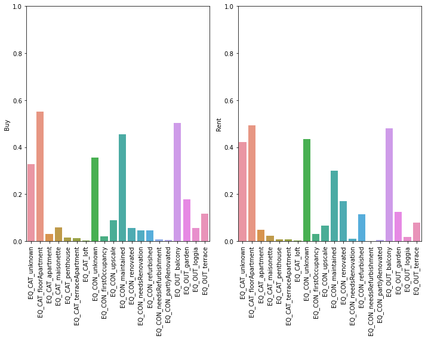

**Results:**

- Distributions regarding apartment-equipment variables differ in some variables between buy & rent:
  - in the offers for buy are less apartments with category 'unknown' or condition 'unknown', 'renovated' or 'refurbished'
  - in the offers for buy are more apartments with condition 'maintained' or which have a garden

## Multivariate Analysis

### Correlation-Heatmap

**Buy:**

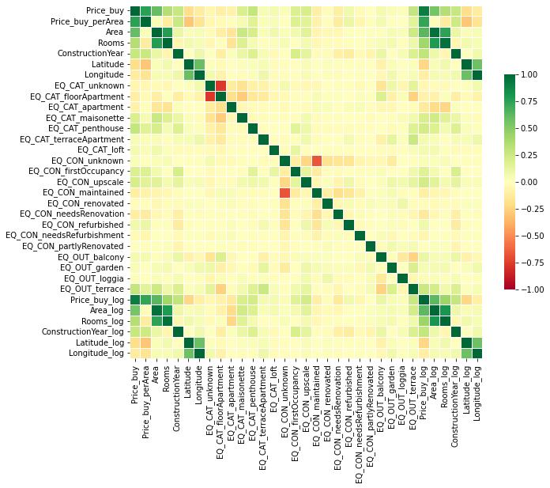

**Rent:**

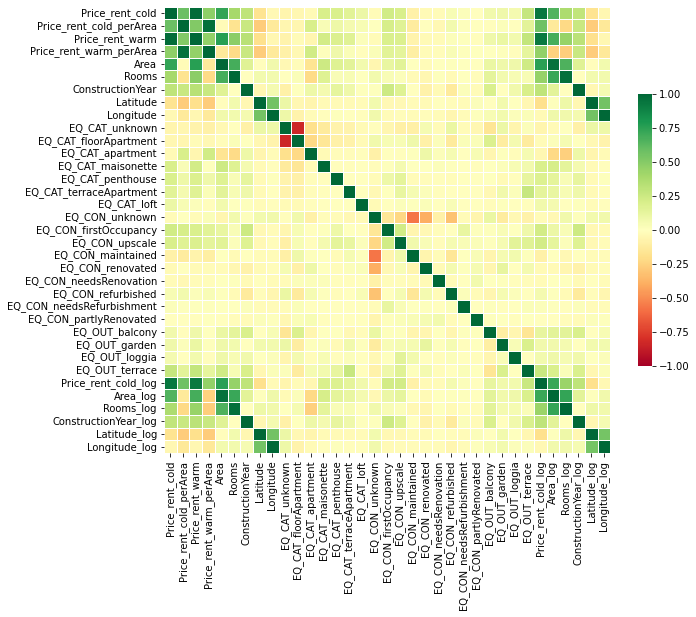

**Results:**

- The correlation of the price variables against the other variables has a very similiar pattern for buy & rent:
  - Strongly positve correlated with 'Area'
  - positive correlated with 'Rooms', 'ConstructionYear', 'EQ_CAT_maisonette', 'EQ_CAT_penthouse', 'EQ_CON_firstOccupancy', 'EQ_CON_upscale', 'EQ_OUT_terrace'
  - interestingly there's no clear positive correlation with 'EQ_OUT_balcony', 'EQ_OUT_garden'
- For most other variables there's no strong correlation between each other - obvious exception is:
  - 'Area' correlates strongly positive with 'Rooms'

### Scatterplots regarding price-variable against numeric variables

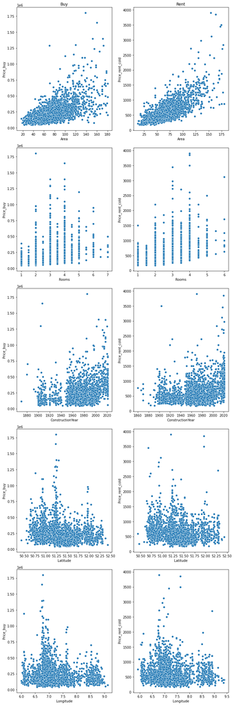

**Results:**

- As already indicated by the correlation-heatmap shown before, the scatterplot visualises the strong positve correlation between the price-variable against 'Area' in detail for buy & rent

### Scatterplots regarding log-transformed price-variable against log-transformed Area- and Rooms-variables

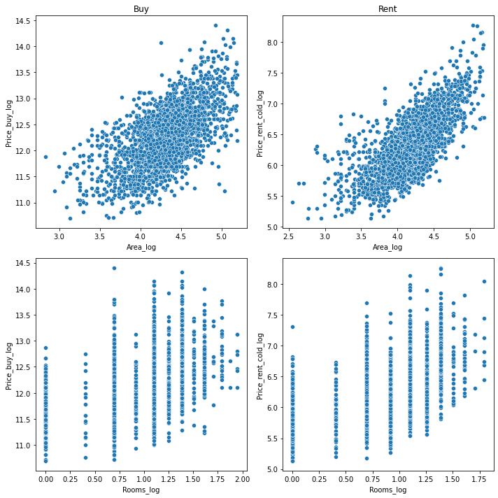

**Results:**

- Thanks to the log-transformation you can see a relative strong linear relationship between the log-transformed Price-variable against the log-transformed Area and Rooms variable

### Barplots regarding price-variable against apartment-equipment variables

Median price of apartment with value = 1 (='Yes') compared to value = 0 (='No') for each apartment-equipment variable.  
Hint: The vertical mini-bar on top of each bar represents the 95% confidence-interval generated by random-sampling (longer mini-bar means higher uncertainty).

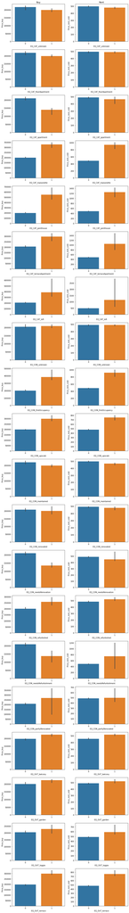

**Results:**

As already indicated by the correlation-heatmap shown before, the barplots visualise that:

- Apartments with categories like 'maisonette', 'penthouse' or 'terraceApartment' have clearly higher median value prices
- Apartments with conditions like 'firstOccupancy' or 'upscale' have clearly higher median value prices
- Apartments with 'terrace' have clearly higher median value prices

## Geographic Analysis

### Geographic distributions of apartments and their prices per area (log-scaled)

**Buy:**

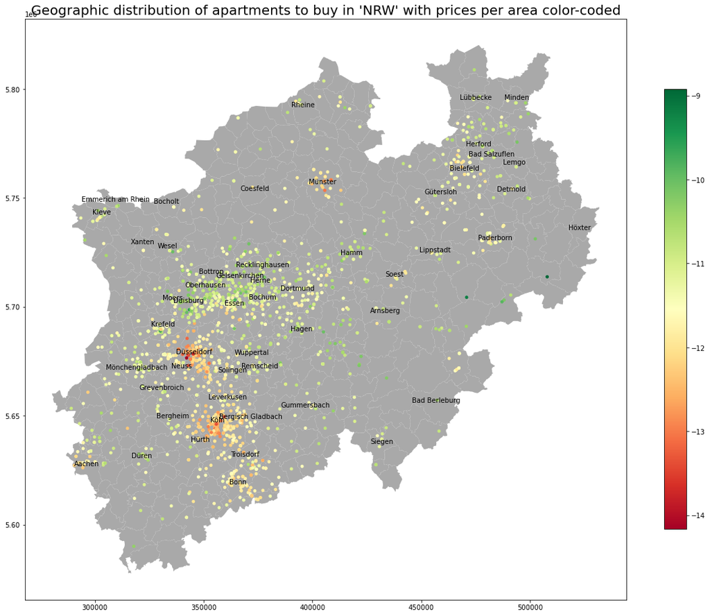

**Rent:**

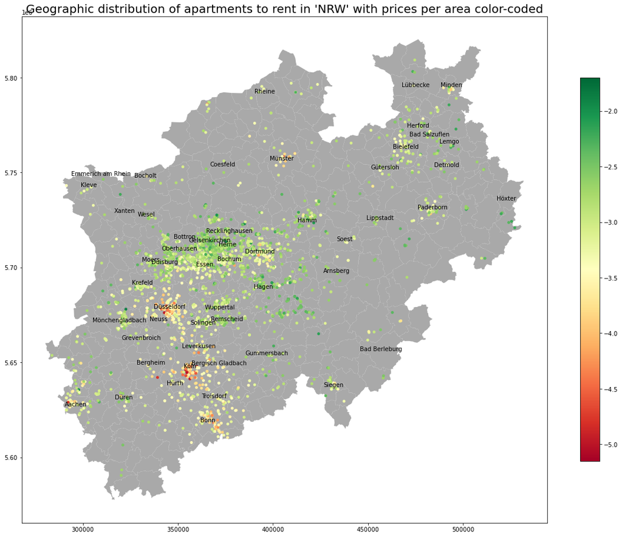

**Results:**

- Similiar pattern regarding the geographic distribution of apartments and prices per area (log-scaled) for buy & rent:
  - Distribution of apartments corresponds to distribution of number of residents in the districts of NRW: Much apartment offers for the dense populated 'Ruhrgebiet' (Duisburg, Essen, Dortmund, ...) and the 'Rhine'-Region (Düsseldorf, Köln, Bonn)
  - Apartment prices are high (=reddish-colored) for the 'Rhine'-Region (Düsseldorf, Köln, Bonn) with their strong economy
  - Apartment prices are low (=greenish-colored) for the northern 'Ruhrgebiet'-Region (Gelsenkirchen, Recklinghausen) with their structural problems and for the districts abroad from economic centers

### City median prices per area

Buy: City median prices per area with at least 20 apartment-offers ordered by Buy_price_per_Area

| City | Buy_price_per_Area count | Buy_price_per_Area median |
| --- | --- | --- |
| Düsseldorf | 184 | 5,025 €/m² |
| Münster | 52 | 4,670 €/m² |
| Köln | 234 | 4,649 €/m² |
| Aachen | 32 | 4,325 €/m² |
| Bonn | 57 | 3,819 €/m² |
| Neuss | 22 | 3,279 €/m² |
| Leverkusen | 28 | 3,255 €/m² |
| Bergisch Gladbach | 27 | 3,159 €/m² |
| Paderborn | 32 | 3,024 €/m² |
| Bielefeld | 53 | 3,000 €/m² |
| Solingen | 28 | 2,806 €/m² |
| Dortmund | 69 | 2,562 €/m² |
| Mülheim an der Ruhr | 25 | 2,386 €/m² |
| Mönchengladbach | 51 | 2,376 €/m² |
| Krefeld | 53 | 2,373 €/m² |
| Essen | 120 | 2,372 €/m² |
| Remscheid | 34 | 2,351 €/m² |
| Wuppertal | 52 | 2,202 €/m² |
| Bochum | 55 | 2,141 €/m² |
| Herne | 33 | 2,006 €/m² |
| Oberhausen | 33 | 1,803 €/m² |
| Hamm | 25 | 1,780 €/m² |
| Duisburg | 92 | 1,718 €/m² |
| Gelsenkirchen | 46 | 1,512 €/m² |

Rent: City median prices per area with at least 20 apartment-offers ordered by Rent_cold_per_Area

| City | Rent_cold_per_Area count | Rent_cold_per_Area median | Rent_warm_per_Area median | Rent_warm_to_cold_difference |
| --- | --- | --- | --- | --- |
| Köln | 85 | 13.2 €/m² | 16.1 €/m² | 2.9 €/m² |
| Münster | 24 | 12.4 €/m² | 15.4 €/m² | 2.9 €/m² |
| Düsseldorf | 161 | 12.1 €/m² | 16.0 €/m² | 4.0 €/m² |
| Bonn | 60 | 12.0 €/m² | 15.5 €/m² | 3.5 €/m² |
| Minden | 24 | 10.7 €/m² | 13.2 €/m² | 2.5 €/m² |
| Aachen | 48 | 10.0 €/m² | 13.4 €/m² | 3.3 €/m² |
| Paderborn | 44 | 8.6 €/m² | 11.3 €/m² | 2.7 €/m² |
| Dortmund | 192 | 8.6 €/m² | 11.7 €/m² | 3.1 €/m² |
| Bielefeld | 50 | 8.6 €/m² | 11.1 €/m² | 2.6 €/m² |
| Mülheim an der Ruhr | 35 | 8.4 €/m² | 11.6 €/m² | 3.2 €/m² |
| Essen | 306 | 8.0 €/m² | 10.9 €/m² | 2.9 €/m² |
| Krefeld | 37 | 8.0 €/m² | 11.0 €/m² | 3.0 €/m² |
| Mönchengladbach | 57 | 7.8 €/m² | 11.5 €/m² | 3.7 €/m² |
| Bochum | 109 | 7.8 €/m² | 11.3 €/m² | 3.5 €/m² |
| Solingen | 32 | 7.7 €/m² | 11.6 €/m² | 3.9 €/m² |
| Bottrop | 28 | 7.5 €/m² | 9.4 €/m² | 1.8 €/m² |
| Siegen | 21 | 7.5 €/m² | 11.9 €/m² | 4.4 €/m² |
| Moers | 26 | 7.5 €/m² | 9.9 €/m² | 2.5 €/m² |
| Wuppertal | 72 | 7.5 €/m² | 10.2 €/m² | 2.7 €/m² |
| Oberhausen | 50 | 7.1 €/m² | 9.8 €/m² | 2.8 €/m² |
| Duisburg | 168 | 7.0 €/m² | 10.1 €/m² | 3.1 €/m² |
| Witten | 22 | 7.0 €/m² | 10.1 €/m² | 3.2 €/m² |
| Iserlohn | 23 | 6.9 €/m² | 10.3 €/m² | 3.4 €/m² |
| Recklinghausen | 27 | 6.9 €/m² | 9.3 €/m² | 2.4 €/m² |
| Hamm | 56 | 6.8 €/m² | 9.3 €/m² | 2.5 €/m² |
| Herne | 99 | 6.7 €/m² | 9.6 €/m² | 2.9 €/m² |
| Marl | 22 | 6.5 €/m² | 9.4 €/m² | 2.9 €/m² |
| Lüdenscheid | 28 | 6.4 €/m² | 9.7 €/m² | 3.3 €/m² |
| Remscheid | 36 | 6.3 €/m² | 9.5 €/m² | 3.1 €/m² |
| Hagen | 65 | 6.1 €/m² | 8.8 €/m² | 2.7 €/m² |
| Gelsenkirchen | 208 | 6.0 €/m² | 8.7 €/m² | 2.7 €/m² |

#### Results:

- There is a huge span in median apartment prices between cities in North Rhine-Westphalia
- Price-order of cities regarding buy compared to rent is similiar
- The difference of Rent_warm_per_Area to Rent_cold_per_Area has a low sensitivity regarding Rent_cold_per_Area and is round about 3 € per square metre.

### Rent-cold to Buy-price ratio

Rent-cold to Buy-price ratio with at least 20 apartment-offers for buy and rent in each case ordered by Rent_cold_to_Buy_ratio

| City | Buy_price_per_Area median | Rent_cold_per_Area median | Rent_cold_to_Buy_price_ratio |
| --- | --- | --- | --- |
| Aachen | 4,325 €/m² | 10.0 €/m² | 2.8% |
| Düsseldorf | 5,025 €/m² | 12.1 €/m² | 2.9% |
| Münster | 4,670 €/m² | 12.4 €/m² | 3.2% |
| Remscheid | 2,351 €/m² | 6.3 €/m² | 3.2% |
| Solingen | 2,806 €/m² | 7.7 €/m² | 3.3% |
| Köln | 4,649 €/m² | 13.2 €/m² | 3.4% |
| Paderborn | 3,024 €/m² | 8.6 €/m² | 3.4% |
| Bielefeld | 3,000 €/m² | 8.6 €/m² | 3.4% |
| Bonn | 3,819 €/m² | 12.0 €/m² | 3.8% |
| Mönchengladbach | 2,376 €/m² | 7.8 €/m² | 3.9% |
| Herne | 2,006 €/m² | 6.7 €/m² | 4.0% |
| Dortmund | 2,562 €/m² | 8.6 €/m² | 4.0% |
| Krefeld | 2,373 €/m² | 8.0 €/m² | 4.0% |
| Essen | 2,372 €/m² | 8.0 €/m² | 4.0% |
| Wuppertal | 2,202 €/m² | 7.5 €/m² | 4.1% |
| Mülheim an der Ruhr | 2,386 €/m² | 8.4 €/m² | 4.2% |
| Bochum | 2,141 €/m² | 7.8 €/m² | 4.4% |
| Hamm | 1,780 €/m² | 6.8 €/m² | 4.6% |
| Oberhausen | 1,803 €/m² | 7.1 €/m² | 4.7% |
| Gelsenkirchen | 1,512 €/m² | 6.0 €/m² | 4.8% |
| Duisburg | 1,718 €/m² | 7.0 €/m² | 4.9% |

#### Correlation of Rent-cold to Buy-price ratio in relation to buy- and rent-price

|  |  | Rent_cold_to_Buy_price_ratio |
| --- | --- | --- |
| Buy_price_per_Area | median | -0.82 |
| Rent_cold_per_Area | median | -0.61 |
| Rent_cold_to_Buy_price_ratio |  | 1.00 |

#### Results:

- Cities differ in their Rent-cold to Buy-price ratio
- Rent-cold to Buy-price ratio has negative correlation with Buy_price_per_Area and Rent_cold_per_Area => expensive cities tend to have a low Rent-cold to Buy-price ratio and cheap cities tend to have a high Rent-cold to Buy-price ratio
- But there are also cities deviating from this relationship, like Remscheid and Solingen: no expensive city in terms of Buy_price_per_Area and Rent_cold_per_Area, but low Rent-cold to Buy-price ratio
- Simple interpretation: It is better to rent in cities with low Rent-cold to Buy-price ratio (like Aachen and Düsseldorf) and it is better to buy in cities with high Rent-cold to Buy-price ratio (like Gelsenkirchen and Duisburg)
- Advanced interpretation in the framework of the [efficient-market hypothesis](https://en.wikipedia.org/wiki/Efficient-market_hypothesis) combined with the [Gordon growth model](https://en.wikipedia.org/wiki/Dividend_discount_model): There is no advantage, but also no disadvantage, to rent in cities with low Rent-cold to Buy-price ratio and vice versa because the apartment market is efficient so that there is no arbitrage-opportunity. Cities with low Rent-cold to buy-price ratio are expected to have higher future rent growth rates compared to cities with high Rent-cold to buy-price ratio => the simple interpretation can be misleading as it does not consider future rent growth rates.

Back to Start